# Assignement 09

Kossi Akplaka

2023-11-04

## Load package

We can load the different package needed to get the data and transform the data

```r
library(tidyverse)
library(httr)
library(jsonlite)
library(tibble)
```

## Detail about the data

I’ll get the data from New York Times API. The website is “https://developer.nytimes.com/docs/archive-product/1/overview”.

“The Archive API returns an array of NYT articles for a given month, going back to 1851. Its response fields are the same as the Article Search API. The Archive API is very useful if you want to build your own database of NYT article metadata. You simply pass the API the year and month and it returns a JSON object with all articles for that month.” (from the NYT description on the overview section.)

## Make API Requests and Parse JSON Data

First, I am going to define the API endpoint, the date and year and month. Fun fact, March is my birthday’s month. So let’s find the article written in Mars 2023.

```r
api_key <- "KgkYJkjApX9MFWRi3DU0K5doqwXPZLij"
year <- 2023
month <- 3

api_endpoint <- paste0("https://api.nytimes.com/svc/archive/v1/", year, "/", month, ".json")
```

Next, we can construct the API request URL.

```r
request_url <- modify_url(api_endpoint, query = list("api-key" = api_key))
```

Now, we can load the data into a data frame.

```r
response <- GET(request_url)
data <- as.data.frame(fromJSON(content(response, as = "text")))
tibble(data)
```

```
## # A tibble: 5,769 × 22
##    copyright  response.docs.abstract response.docs.web_url response.docs.snippet
##    <chr>      <chr>                  <chr>                 <chr>
##  1 Copyright… Now we need to help K… https://www.nytimes.… Now we need to help …
##  2 Copyright… She had been a Manson… https://www.nytimes.… She had been a Manso…
##  3 Copyright… Some Republicans and … https://www.nytimes.… Some Republicans and…
##  4 Copyright… Laura Kavanagh, the f… https://www.nytimes.… Laura Kavanagh, the …
##  5 Copyright… Parker Posey stars in… https://www.nytimes.… Parker Posey stars i…
##  6 Copyright… See full results and … https://www.nytimes.… See full results and…
##  7 Copyright… Executives and top ho… https://www.nytimes.… Executives and top h…
##  8 Copyright… Bryant, the widow of … https://www.nytimes.… Bryant, the widow of…
##  9 Copyright… The U.S. secretary of… https://www.nytimes.… The U.S. secretary o…
## 10 Copyright… Mayor Eric Adams also… https://www.nytimes.… Mayor Eric Adams als…
## # ℹ 5,759 more rows
## # ℹ 18 more variables: response.docs.lead_paragraph <chr>,
## #   response.docs.print_section <chr>, response.docs.print_page <chr>,
## #   response.docs.source <chr>, response.docs.multimedia <list>,
## #   response.docs.headline <df[,7]>, response.docs.keywords <list>,
## #   response.docs.pub_date <chr>, response.docs.document_type <chr>,
## #   response.docs.news_desk <chr>, response.docs.section_name <chr>, …
```

The data returns an array of NYT articles for the month of March, 2023.

## Data Tidying

Let’s gave a glimpse of the data. The data has a total of 5,769 articles written in March 2023.

```r
glimpse(data)
```

```
## Rows: 5,769
## Columns: 22
## $ copyright                      <chr> "Copyright (c) 2023 The New York Times …
## $ response.docs.abstract         <chr> "Now we need to help Kyiv win decisivel…
## $ response.docs.web_url          <chr> "https://www.nytimes.com/2023/02/28/opi…
## $ response.docs.snippet          <chr> "Now we need to help Kyiv win decisivel…
## $ response.docs.lead_paragraph   <chr> "To President Emmanuel Macron of France…
## $ response.docs.print_section    <chr> "A", "B", "A", "A", "C", NA, "B", "B", …
## $ response.docs.print_page       <chr> "19", "8", "13", "17", "1", NA, "1", "8…
## $ response.docs.source           <chr> "The New York Times", "The New York Tim…
## $ response.docs.multimedia       <list> [<data.frame[5 x 11]>], [<data.frame[5…
## $ response.docs.headline         <df[,7]> <data.frame[26 x 7]>
## $ response.docs.keywords         <list> [<data.frame[8 x 4]>], [<data.frame[…
## $ response.docs.pub_date         <chr> "2023-03-01T00:00:07+0000", "2023-03-0…
## $ response.docs.document_type    <chr> "article", "article", "article", "artic…
## $ response.docs.news_desk        <chr> "OpEd", "Obits", "Washington", "Metro",…
## $ response.docs.section_name     <chr> "Opinion", "U.S.", "U.S.", "New York", …
## $ response.docs.byline           <df[,3]> <data.frame[26 x 3]>
## $ response.docs.type_of_material <chr> "Op-Ed", "Obituary (Obit)", "News", "Ne…
## $ response.docs._id              <chr> "nyt://article/522efb9c-f5d0-5a98-ae…
## $ response.docs.word_count       <int> 921, 1300, 1041, 923, 1112, 0, 1237, 70…
## $ response.docs.uri              <chr> "nyt://article/522efb9c-f5d0-5a98-ae64-…
## $ response.docs.subsection_name  <chr> NA, NA, "Politics", NA, NA, "Elections"…
## $ response.hits                  <int> 5769, 5769, 5769, 5769, 5769, 5769, 576…
```

Certain columns are collections of data frames. Let’s have a look of the headline column “response.docs.headline” in the data frame. It is a data frame of 7 columns.

```r
headline_df <- data %>%
  select(response.docs.headline) %>%
  unnest_wider(response.docs.headline)

head(headline_df)
```

```
## # A tibble: 6 × 7
##   main                    kicker content_kicker print_headline name  seo   sub
##   <chr>                   <chr>  <lgl>          <chr>          <lgl> <lgl> <lgl>
## 1 On Ukraine, Biden Outs… Bret … NA             "Gratitude fo… NA    NA    NA
## 2 Linda Kasabian, 73, Di… <NA>   NA             "Linda Kasabi… NA    NA    NA
## 3 Lawmakers Question Pen… <NA>   NA             "Lawmakers Qu… NA    NA    NA
## 4 After a Difficult Debu… <NA>   NA             "In Lawsuit, … NA    NA    NA
## 5 Review: A ‘Seagull’ Ai… <NA>   NA             "In This Chek… NA    NA    NA
## 6 Chicago Municipal Elec… <NA>   NA             ""             NA    NA    NA
```

## Data Analysis

I would like to know the top 10 category of news NYT covered in March 2023. Let’s look at the column “response.docs.news_desk” in the data frame.

View the head of the column

```r
head(data$response.docs.news_desk)
```

```
## [1] "OpEd"       "Obits"      "Washington" "Metro"      "Culture"
## [6] "Graphics"
```

Create a data frame of the top 10 category

```r
# Find the top 10
top10 <- head(sort(table(data$response.docs.news_desk), decreasing = TRUE), 10)
# Create a data frame
data_top10 <- data.frame(Category = names(top10), Count = as.numeric(top10))
data_top10
```

```
##      Category Count
## 1    Graphics  1959
## 2     Foreign   405
## 3    Business   315
## 4     Culture   287
## 5        OpEd   257
## 6  Washington   200
## 7      Sports   196
## 8       Metro   160
## 9      Styles   144
## 10    Express   140
```

It seems like NYT covers Graphics way more than the other topics.Let’s plot the top 10 categories

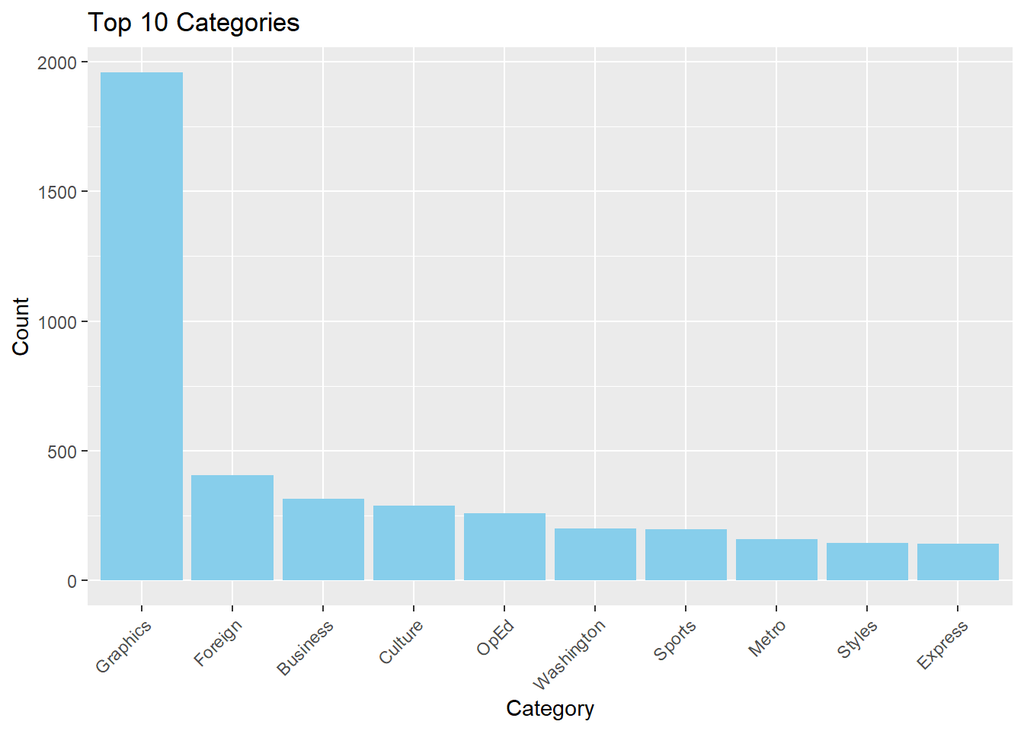

```r
# Create a bar plot
ggplot(data_top10, aes(x = reorder(Category,-Count),  y = Count)) +
  geom_bar(stat = "identity", fill = 'skyblue') +
  labs(title = "Top 10 Categories",
       x = "Category",
       y = "Count") +
  theme(axis.text.x = element_text(angle = 45, hjust = 1))
```